# AS6-2

第十六組

2019/3/29

[figure not shown]

```r
# Frame
plot(0,0,xlim=c(40,100),ylim=c(0,1.1),xlab="噴發時間(分鐘)",
     ylab="密度 or (累計)機率", main="分布、機率與密度",family="Arial Unicode MS")
abline(h=1, col='lightgray', lwd=0.25, lty=2)

# Empirical PDF
rug(D)
# Empirical CDF
plot(ecdf(D), cex=0, verticals=T, lwd=2, col='darkgray', add=T)

# Histogram PDF
Bins = 20                             # no. bins
bx = seq(min(D), max(D), length=Bins) # break sequence
hist(D, col="#B3FFFF7F", border="white", ylim=c(0,1.1),
     freq=F, breaks=bx, add=T)
abline(h=0, col='lightgray', lwd=0.25)
# Histogram CDF
adj = (bx[2] - bx[1])/2
steps = stepfun(bx-adj, c(0, sapply(bx, function(b) mean(D <= b))))
plot(steps, cex=0, col='#33CC337F', lwd=3, lty=1, add=T)

# Smooth PDF
Adjust = 0.5    # bandwidth adjustment
DEN = density(D, adjust = Adjust)
lines(DEN, col='gold', lwd=3)
# Smooth CDF
PDF = approxfun(DEN$x, DEN$y, yleft=0, yright=0)
x = seq(40,100,10)
y = sapply(x, function(i) integrate(PDF, -Inf, i)$value)
lines(x, y, col='red', lwd=3, lty=2)

# Mark Range
x1 = 80; x2 = 90
rect(x1,-0.1,x2,1.2,col= rgb(0,1,0,alpha=0.2),border=NA)
```

```r
# x = seq(x1, x2, length=100)
# polygon(c(x, x2, x1),  c(PDF(x), 0, 0), col="#FF99003F", border=NA)
# Calculate Probability
(integrate(PDF, x1, x2)$value)
```

```
## [1] 0.2827451
```

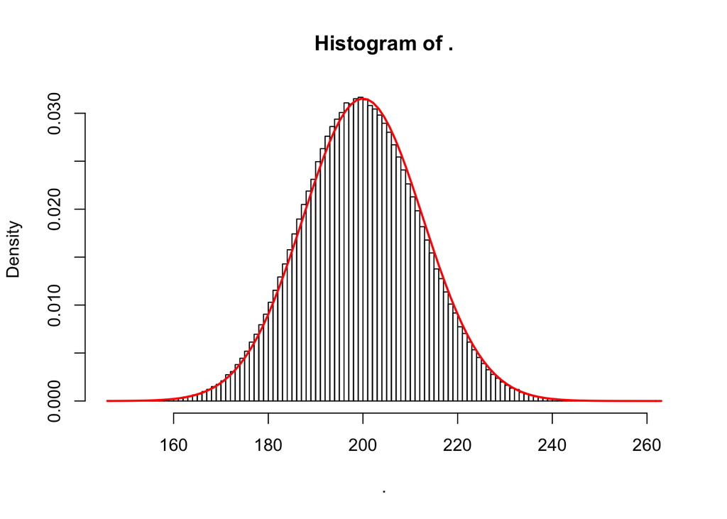

```r
###############################
library('dplyr')
rbinom(1000000, 1000, 0.2) %>% hist(breaks=100,freq=F)
curve(dnorm(x,mean=200,sd=sqrt(160)), col='red', lwd=2, add=T)
```

【A.選擇方法】  
■ 我們為甚麼需要隨機變數？ 什麼時候我們需要用到隨機變數？  
##隨機變數能夠幫助我們以抽樣的方式去試圖理解母體的狀態。有時針對母體作普查的成本太高時，便會選擇使用隨機變數去進行隨機抽樣。

■ 隨機變數沒有固定的值，那我們要如何做計算呢？  
##隨機變數的機率函數圖形下方面積為機率值，可用此來做計算。

■ 我們可以用直方圖或數值標記來估計噴發時間落在某一區間的機率嗎？  
##可以。

■ 直方圖(histogram)也可以當作一種模型嗎？ 數值標記(rug)呢？  
##直方圖可以作為一種模型，能夠描述相對次數（機率密度）的分配情況。數值標記也可以，若是樣本數夠大，達到連續型隨變數之分佈狀態 ，便能得到pdf函數，及可作為模型。

■ 直方圖和平滑模型哪一個比較適合用來表示噴發時間的分布？ 為甚麼？  
##平滑模型，因為噴發時間單點從數學角度來看，每個單點的機率都是0，即為連續型機率密度函數概念，故平滑模型比較適合作為噴發時間 的發佈。

■ 用數值標記來預測噴發時間會比用直方圖「準」嗎？ 「準」是什麼意思呢？  
##會。當抽樣數夠大時，可視為無限母體，並透過數值標記來推論母體，形成一個連續型函數的概念，如此一來便能得到「不偏估計量」，同 時也是追求統計上的「有效性」，能夠以MSE（平均平方誤差）來評估其準確度。

【B.調整參數】調整一下模型參數的滑桿 …  
■ 你覺得最合適的直方圖欄數(support/binwidth)是？ 為甚麼？  
##欄位數：18時，形成兩個雙峰分配，未有某單點機率密度過高的問題，且此種情況適合使用RAM Model來做處理。

■ 最合適的平滑模型頻寬(bandwidth)呢？  
##最合適的平滑模型頻寬：0.6。

■ 調高欄寬和頻寬會讓模型變複雜，還是變簡單呢？  
##會使模型變簡單，過低會有under-fitting的問題。

■ 模型越複雜，它跟實際值之間的誤差是越大、還是越小？  
##越小，模型越複雜，擬合度就會越高，則與實際值之間的誤差便會越小。

■ 那麼，越複雜的模型就會越準，對嗎？  
##不一定，「準」的定義若是建立在「解釋」上，越複雜的模型，解釋力越高。但「準」的定義若是「預測」上，則會使模型預測力失真，反 而失去預測能力。

【C.建立模型、估計機率】  
請從課堂筆記的程式碼找出來 …  
■ 從變數向量(D)求出機率密度曲線(DEN)  
■ 將機率密度曲線(DEN)轉換成機率密度函數(PDF)  
■ 對機率密度函數(PDF)做積分，算出機率(PROB)

這三行程式，然後…

■ 將頻寬調整參數(adjust)設為1，算出「等待時間」落在80到90之間的機率  
##0.26851

■ 將頻寬調整參數設為0.5，算出等待時間落在80到90之間的機率  
##0.28275

■ 算出來的機率比較高的就是比較好的模型，對嗎？ 為甚麼？  
##不對，當頻寬為1時，平滑曲線所覆蓋之樣本點的數量比頻寬為0.5時高的，較能完整描述樣本實際分布狀況。

【D.預測與決策】  
假設有一個賭局，你可以花30元選定一個連續60秒的時段，如果老忠實下一次的噴發時間落在你指定的區間，你就可以贏到100元；請你使用 頻寬為0.5的平滑密度模型 …  
■ 決定要不要參加這個賭局  
##要。

■ 如果你參加的話，你要把噴發時間設定在哪一個區間呢？  
##將區間設在3.9分到4.9分之間。

■ 你設在這個區間的話，參加這個賭局的期望值是？  
##期望值為：(-30)*(1-0.477)+70*0.477 = 17.7

```r
D =faithful$eruptions
x=seq(1,6,1/6)
Y=function(x){prob= integrate(PDF, x, (x+1/6))$value
95*prob+(-5)*(1-prob)}
exp=sapply(x,Y)
a=data.frame(x,exp)
a[a$exp>0,]
```

```
## [1] x   exp
## <0 rows> (or 0-length row.names)
```

將獲利的期望值和賭金的比值稱為「期望投資報酬率」 …  
■ 「最大期望投資報酬率」和「最大期望報酬」的投資策略是一樣的嗎？  
##不太相同，前者需要考慮風險，當機率密度函數能完整覆蓋長條圖時才進行下注，因為風險是不可預期的。然而，後者則不用考慮風險，只要有噴就賭。

■ 你認為哪一個策略目標比較好呢？ 為什麼？  
##不一定，看個人的風險喜好程度，因為市場上本來就存在著風險。不過我們組都喜歡後者